# Summarizing and Displaying Data

by* [*Michael L. Bernauer*](http://mlbernauer.bitbucket.org/)

02/26/2015

## Graphical summaries for one quantitative sample

### Histograms

The histogram breaks the range of data into smaller number of equal-width intervals (bins) producing graphical information about the observed distribution by highlighting where data values cluster. The histogram can use arbitrary intervals.

```
## stat_bin: binwidth defaulted to range/30. Use 'binwidth = x' to adjust this.
```

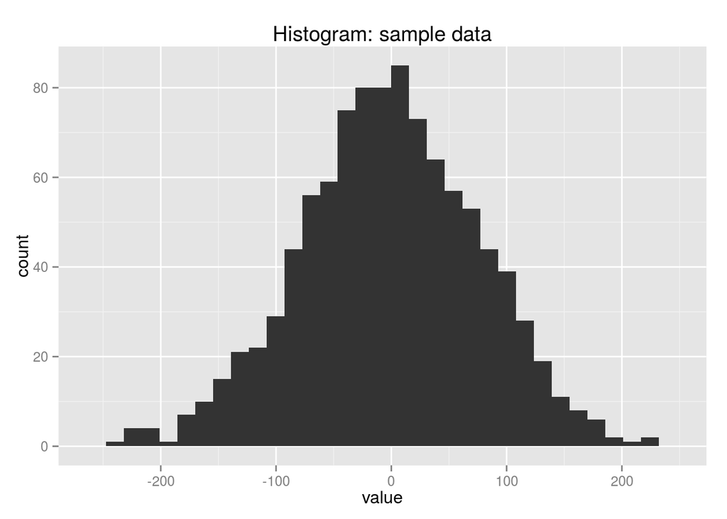

```r
require(ggplot2)
# Some sample data
sample_data <- 75 * rnorm(1000)
sample_data <- data.frame(sample_data)

# Histogram
ggplot(sample_data, aes(x=sample_data)) + geom_histogram() +
  labs(title="Histogram: sample data") + ylab("count") + xlab("value")
```

#### Improvements to the histogram

The histogram can be improved by overlaying a kernel density function to give the viewer an idea about the continuous distribution of the data and by plotting the data points below with some jitter

```
## stat_bin: binwidth defaulted to range/30. Use 'binwidth = x' to adjust this.
```

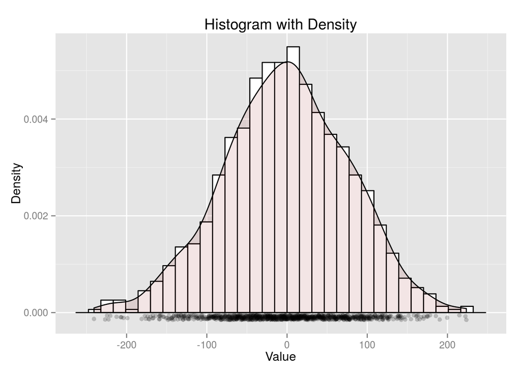

```r
ggplot(sample_data, aes(x=sample_data)) + geom_histogram(aes(y=..density..), fill="white", color='black') +
  geom_density(alpha=0.1, fill="darkred") + geom_point(aes(y=-0.0001), alpha=0.20, position=position_jitter(height=0.00005)) +
  labs(title="Histogram with Density") + ylab("Density") + xlab("Value")
```

### Boxplot

The boxplot breaks up the range of data values into regions about the center of the data, measured by the median. The boxplot highlights outliers and provides a visual means to assess **normality**. The endpoints of the box are placed at the locations of the first and third quartiles. The location of the median is identified by the line in the box. The whiskers extend to the data points closest to but not on or outside the outlier fences, which are $1.5IQR$ from quartiles. Outliers are any values outside the whiskers.

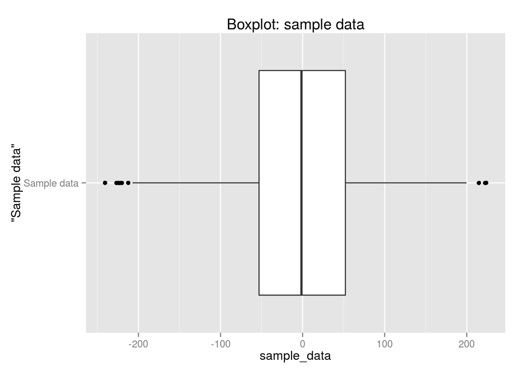

```r
ggplot(sample_data) + geom_boxplot(aes(x = "Sample data", y = sample_data)) + coord_flip() +
  labs(title="Boxplot: sample data")
```

#### Improvements to the boxplot

The violin plot is a combination of a boxplot and a kernel density plot. They can be created using the `geom_violin()` in `ggplot2`.

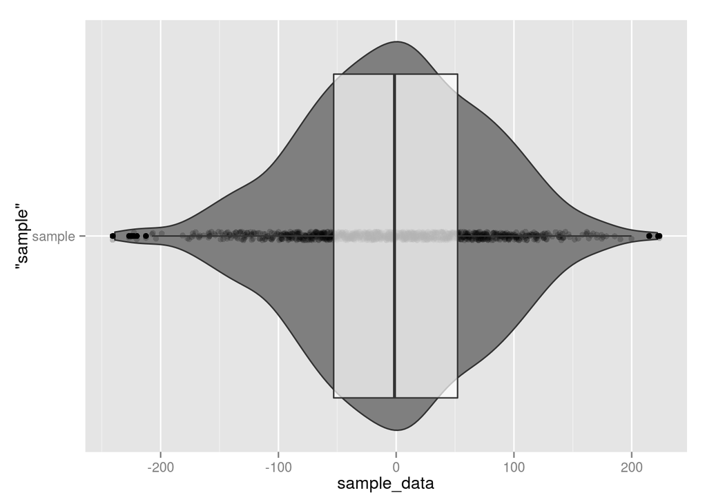

```r
ggplot(sample_data, aes(x="sample", y=sample_data)) + geom_violin(fill="gray50") +
  geom_point(position = position_jitter(width=0.01), alpha=0.2) +
  geom_boxplot(alpha=0.7) + coord_flip()
```